# Resolución Desafio Técnico TELECOM/Cablevisión

Lautaro Cantar

9/2/2020

## 1. Test SQL

El resultado final consiste en construir una tabla que contenga las siguientes columnas:

- Domicilio
- Cantidad de líneas fijas
- Cantidad de líneas móviles
- Cantidad de personas titulares de algún servicio
- Si tiene o no tiene internet
- Si tiene o no tiene cable

### 1.1 Ejercicio 1

Para la creación de la tabla objetivo, es necesario utilizar la información proveniente de las cuatro tablas disponibles: `CLTES_TEL_FIJA`, `CLTES_CABLE_INTER`, `CLTES_TEL_MOVIL` y `CRUCE_DOMICILIO`.

#### 1.1.1 Mismos nombres de calles

Una problemática es que en las tabla `CLTES_TEL_FIJA` y `CLTES_CABLE_INTER` no utilizan la misma definición para el nombre de las calles, por lo tanto el primer desafío es que ambas tablas utilicen el mismo nombre para las mismas calles. La solución plantea es partiendo de la tabla `CLTES_TEL_FIJA`, unirle la columna `CALLE_B` de la tabla `CRUCE_DOMICILIO`, utilizando la variable `COD_CALLE_LOC_A`.

Esta problematica se soluciona creando la tabla soporte `SOP_CLTES_TEL_FIJO` con la siguiente query.

```r
CREATE TEMP TABLE SOP_CLTES_TEL_FIJO as
  SELECT cltes_tel_fija.*, cruce_domicilios.cod_calle_a, cruce_domicilios.calle_b
  FROM cltes_tel_fija
  LEFT JOIN cruce_domicilios
  on cltes_tel_fija.cod_calle_a == cruce_domicilios.cod_calle_a
```

#### 1.1.2 Tabla RESUMEN_TEL_FIJA

El siguiente paso es construir una tabla resumen que agrupe la cantidad de **Cantidad de líneas fijas** y **Cantidad de personas titulares de líneas fijas** según Domicilio.

Para eso se crea una la tabla `SOP_CLTES_TEL_FIJO_2` para crear la variable `DOMICILIO` uniendo las variables `CALLE_B`, `ALTURA_A`, `LOCALIDAD_A` y `PROVINCIA_A`.

```r
CREATE TABLE SOP_CLTES_TEL_FIJO_2 AS
  SELECT  *, CALLE_B || ' ' || ALTURA_A || ' ' || LOCALIDAD_A || ' ' || PROVINCIA_A AS DOMICILIO
  FROM SOP_CLTES_TEL_FIJO
```

Y con la tabla `SOP_CLTES_TEL_FIJO_2` finalmente creamos la tabla `RESUMEN_TEL_FIJA` que va a tener las siguientes variables:

- Domicilio
- Cantidad de líneas fijas
- Cantidad de personas titulares de líneas fijas

```r
CREATE TABLE RESUMEN_TEL_FIJA as
SELECT domicilio, COUNT(DISTINCT(nro_linea_fija)) AS nro_lineas_fijas, COUNT(DISTINCT(nro_doc)) AS nro_titulares_fija
FROM sop_cltes_tel_fijo_2
GROUP by domicilio
```

#### 1.1.3 Tabla RESUMEN_CABLE_INTERNET

En este apartado vamos a crear una tabla similar a `RESUMEN_TEL_FIJA` pero utilizando los datos provenientes de la tabla `CLTES_CABLE_INTER`. En primera instancia volvemos a crear una variable `DOMICILIO` en una tabla temporal `SOP_CLTES_CABLE_INTER`.

```r
CREATE TABLE SOP_CLTES_CABLE_INTER AS
SELECT *, CALLE_B || ' ' || ALTURA_B || ' ' || LOCALIDAD_B || ' ' || PROVINCIA_B as DOMICILIO
FROM cltes_cable_inter
```

Utilizando la tabla soporte, creamos finalmente la tabla `RESUMEN_CABLE_INTER` que tendrá las siguientes variables:

- Domicilio
- Cantidad de personas titulares cable/internet
- Si tiene o no tiene internet
- Si tiene o no tiene cable

```r
CREATE TABLE RESUMEN_CABLE_INTER AS
SELECT DOMICILIO, count(distinct(nro_doc)) AS nro_titulares_cable
FROM sop_cltes_cable_inter
GROUP BY domicilio
```

Adicionalmente creo una tabla temporal llamada `SOP_CLTES_CABLE_INTER_2` que me va a ayudar a crear la tabla final.

```r
CREATE TEMP TABLE sop_cltes_cable_inter_2 AS
SELECT domicilio, tiene_internet, tiene_cable
FROM sop_cltes_cable_inter
```

#### 1.1.3 Tabla RESUMEN_MOVIL

```r
CREATE TABLE RESUMEN_MOVIL AS
SELECT nro_doc, count(distinct(nro_doc)) as nro_moviles
from cltes_tel_movil
GROUP by nro_doc
```

#### 1.1.4 Creando la tabla final

Para empezar a crear la tabla final voy a crear una nueva tabla, llamada `TABLA_FINAL` que se crea con las variables `DOMICILIO` y `NRO_DOC` de las tablas soportes creadas anteriormente `SOP_CLTES_CABLE_INTER` y `SOP_CLTES_TEL_FIJO_2`.

```r
CREATE TABLE TABLA_FINAL AS
SELECT DOMICILIO, nro_doc
FROM SOP_CLTES_TEL_FIJO_2
UNION SELECT DOMICILIO, nro_doc
FROM SOP_CLTES_CABLE_INTER
```

A esta tabla le uniré los datos de las tablas resumen realizadas con anterioridad:

```r
CREATE TEMP TABLE TABLA_FINAL_2 AS
SELECT *
from TABLA_FINAL
left OUTER JOIN RESUMEN_TEL_FIJA using (domicilio)
left OUTER JOIN RESUMEN_CABLE_INTER using (domicilio)
left OUTER JOIN RESUMEN_MOVIL using (nro_doc)
left OUTER JOIN sop_cltes_cable_inter_2 using (domicilio)
```

Por último, se crea la tabla final del desafío `TABLA_DESAFIO` en la que se quita la columna `NRO_DOC` y se suman las variables `NRO_TITULAES_CABLE` y `NRO_TITURALES_FIJA` en una sola columna llamada `NRO_TITULARES`.

```r
CREATE TABLE TABLA_DESAFIO AS
SELECT domicilio, nro_lineas_fijas, nro_moviles, IFNULL(nro_titulares_cable, 0) + IFNULL(nro_titulares_fija,0) as nro_titulares, tiene_internet, tiene_cable
from TABLA_FINAL_2
```

### 1.2 Ejercicio 2

Las queries para los siguientes ejercicios serían las siguientes:

1. CANTIDAD DE DOMICILIOS CON AL MENOS UNA LINEA FIJA

```r
SELECT COUNT(DOMICILIO)
FROM TABLA_DESAFIO
WHERE nro_lineas_fijas >= 1
```

2. CANTIDAD DE DOMICILIOS CON AL MENOS UNA LINEA MOVIL

```r
SELECT COUNT(DOMICILIO)
FROM TABLA_DESAFIO
WHERE nro_moviles >= 1
```

3. CANTIDAD DE DOMICILIOS CON INTERNET

```r
SELECT COUNT(DOMICILIO)
FROM TABLA_DESAFIO
WHERE tiene_internet >= 1
```

4. CANTIDAD DE DOMICILIOS CON CABLE

```r
SELECT COUNT(DOMICILIO)
FROM TABLA_DESAFIO
WHERE tiene_cable >= 1
```

5. CANTIDAD DE DOMICILIOS QUE POSEEN LOS 4 PRODUCTOS

```r
SELECT COUNT(DOMICILIO)
FROM TABLA_DESAFIO
WHERE nro_lineas_fijas >= 1 AND nro_moviles >= 1 AND tiene_cable >= 1 and tiene_internet >= 1
```

Una vez realizadas las queries, el tablero de control lo armaría de la siguiente manera:

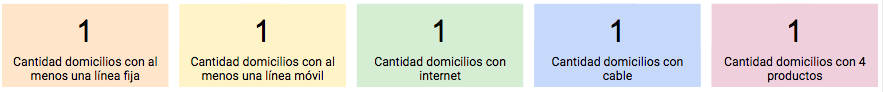

## 2. Tablero KPI

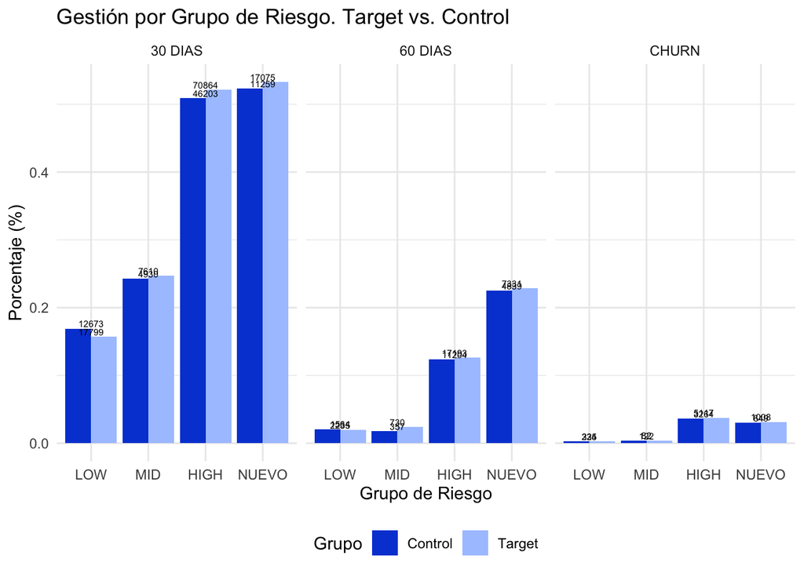

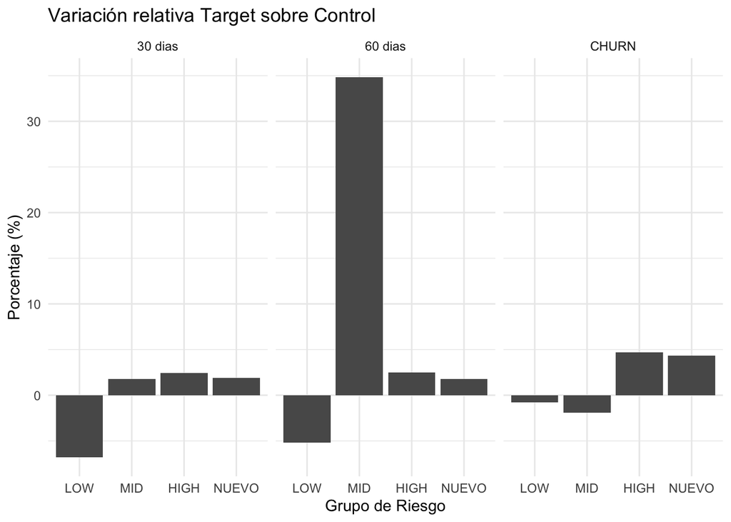

```r
# La resolución de este ejercicio fue realizada utilizando el software R

# Cargando los paquetes
library(tidyverse)
library(readxl)
library(janitor)

# Abriendo los datos
dat <- read_excel("Evaluacion_imp_V2/Test Tablero KPIS V2.xlsx")

# Editando los datos
dat <- dat[,c(1:9)] %>%
  mutate(GRUPO_RIESGO = factor(GRUPO_RIESGO,
                               levels =  c("LOW", "MID", "HIGH", "NUEVO"),
                               ordered = TRUE),
         GRUPO = GRUPO %>% as.factor(),
         GRUPO = recode(GRUPO,
                        "1" = "Target",
                        '0' = "Control"),
         FLG_MORA_30D = case_when(is.na(FLG_MORA_30D) ~ 0,
                                  TRUE ~ FLG_MORA_30D),
         FLG_MORA_60D = case_when(is.na(FLG_MORA_60D) ~ 0,
                                  TRUE ~ FLG_MORA_60D),
         CHURN = case_when(is.na(CHURN) ~ 0,
                                  TRUE ~ CHURN))

# Definiendo funciones para agilizar el análisis de los datos

# Variación porcentual
variacion_porcentual <- function(d){

  g1 <- d %>%
    filter(GRUPO == "Target") %>%
    select(percent)

  g0 <- d %>%
    filter(GRUPO == "Control") %>%
    select(percent)

  vp <- (g1/g0 -1)* 100 %>% as.numeric()

  return(vp)
}

# Cambio en mora 30 días
calculo_porcentaje_30 <- function(gr){

  d <- dat %>%
    filter(GRUPO_RIESGO == gr) %>%
    group_by(GRUPO) %>%
    summarise(clientes_totales = sum(Q),
              clientes_en_mora = sum(Q[FLG_MORA_30D == 1])) %>%
    mutate(percent = clientes_en_mora / clientes_totales,
           GRUPO_RIESGO = gr,
           MORA = "30 DIAS")

  return(d)
}

# Cambio en mora 60 días
calculo_porcentaje_60 <- function(gr){

  d <- dat %>%
    filter(GRUPO_RIESGO == gr) %>%
    group_by(GRUPO) %>%
    summarise(clientes_totales = sum(Q),
              clientes_en_mora = sum(Q[FLG_MORA_60D == 1])) %>%
    mutate(percent = clientes_en_mora / clientes_totales,
           GRUPO_RIESGO = gr,
           MORA = "60 DIAS")

  return(d)
}

# Cambio en baja por churn
calculo_porcentaje_churn <- function(gr){

  d <- dat %>%
    filter(GRUPO_RIESGO == gr) %>%
    group_by(GRUPO) %>%
    summarise(clientes_totales = sum(Q),
              clientes_en_mora = sum(Q[CHURN == 1])) %>%
    mutate(percent = clientes_en_mora / clientes_totales,
           GRUPO_RIESGO = gr,
           MORA = "CHURN")

  return(d)
}


grupos_riesgo <- c("LOW", "MID", "HIGH", "NUEVO")


# 30 días

d_30 <-  data.frame()
var_30 <-  data.frame()

for (i in 1:length(grupos_riesgo)) {

  gr <- grupos_riesgo[i]

  d <- calculo_porcentaje_30(gr)

  d_30 <- rbind(d_30, d)

  d_var <- data.frame(GRUPO_RIESGO = gr,
                      var = variacion_porcentual(d))

  var_30 <- rbind(var_30, d_var)
}


# 60 días

d_60 <-  data.frame()
var_60 <-  data.frame()

for (i in 1:length(grupos_riesgo)) {

  gr <- grupos_riesgo[i]

  d <- calculo_porcentaje_60(gr)

  d_60 <- rbind(d_60, d)

  d_var <- data.frame(GRUPO_RIESGO = gr,
                      var = variacion_porcentual(d))

  var_60 <- rbind(var_60, d_var)
}


# churn días

d_churn <-  data.frame()
var_churn <-  data.frame()

for (i in 1:length(grupos_riesgo)) {

  gr <- grupos_riesgo[i]

  d <- calculo_porcentaje_churn(gr)

  d_churn <- rbind(d_churn, d)

  d_var <- data.frame(GRUPO_RIESGO = gr,
                      var = variacion_porcentual(d))

  var_churn <- rbind(var_churn, d_var)
}

# Uniendo los subsets sobre datos referidos a mora
d_mora <- rbind(d_30, d_60, d_churn) %>%
  mutate(#GRUPO = case_when(GRUPO == 0 ~ "Control",
                           # GRUPO == 1 ~ "Target"),
         GRUPO_RIESGO = factor(GRUPO_RIESGO,
                               levels =  c("LOW", "MID", "HIGH", "NUEVO"),
                               ordered = TRUE))
# Gráfico
grafico_gestion <- ggplot() +
  geom_bar(data = d_mora,
           aes(x = GRUPO_RIESGO, y = percent, fill = factor(GRUPO)),
           stat = "identity",
           position = "dodge") +
  geom_text(data = d_mora,
            aes(x = GRUPO_RIESGO, y = percent, label = clientes_en_mora),
            position = position_dodge(width = 0.9),
            vjust=-0.25, size = 2) +
  facet_wrap(~ MORA) +
  labs(title = "Gestión por Grupo de Riesgo. Target vs. Control",
       x = "Grupo de Riesgo",
       y = "Porcentaje (%)",
       fill = "Grupo") +
  scale_fill_manual(values = c("#0648d6", "#abc6ff" )) +
  theme_minimal() +
  theme(legend.position = "bottom")


# Uniendo los subsets de variación
var_mora <- rbind(var_30 %>%
                    mutate(MORA = "30 dias"),
                  var_60 %>%
                    mutate(MORA = "60 dias"),
                  var_churn %>% mutate(MORA = "CHURN"))

# Gráfico
grafico_variacion <- ggplot() +
  geom_bar(data = var_mora,
           aes(x = GRUPO_RIESGO, y = percent), stat = "identity") +
  facet_wrap(~ MORA) +
  labs(title = "Variación relativa Target sobre Control",
       x = "Grupo de Riesgo",
       y = "Porcentaje (%)",
       fill = "Grupo") +
  theme_minimal()
```

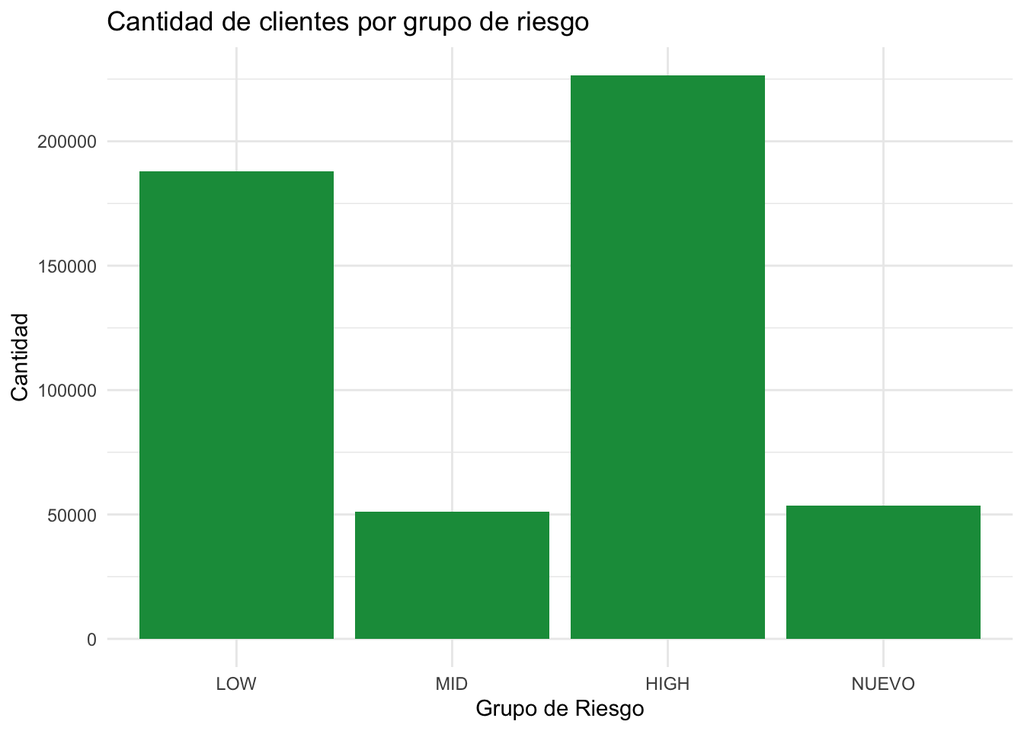

```r
grafico_poblaciones_dat <- dat %>%
  group_by(GRUPO_RIESGO) %>%
  summarise(cantidad_clientes = sum(Q))

ggplot() +
  geom_bar(data = grafico_poblaciones_dat,
           aes(x = GRUPO_RIESGO, y = cantidad_clientes),
           fill = "#179949",
           stat = "identity") +
  labs(title = "Cantidad de clientes por grupo de riesgo",
       x = "Grupo de Riesgo",
       y = "Cantidad") +
  theme_minimal()
```

## 3. Extra

```r
dat <- dat %>%
  # Incorporando los valores de  la consigna
  mutate(ingreso_cantidad = Ingreso * Q,
         costo = case_when(GRUPO == "Target" ~ 130,
                           GRUPO == "Control" & GRUPO_RIESGO == "LOW" ~ 50,
                           GRUPO == "Control" & GRUPO_RIESGO == "MID" ~ 50,
                           GRUPO == "Control" & GRUPO_RIESGO == "HIGH" ~ 150,
                           GRUPO == "Control" & GRUPO_RIESGO == "NUEVO" ~ 150),
         costo_cantidad = costo * Q,
         ingreso_neto = ingreso_cantidad - costo_cantidad)
```

### 3.1 Pregunta 1

```r
# Calculando la pregunta 1
extra_p1 <- dat %>%
  filter(CHURN != 0) %>% # Descartando los casos de CHURN
  group_by(GRUPO) %>%
  summarise(ingresos_totales = sum(ingreso_neto))
```

La estrategía que le genera mayores ingresos a la empresa es la llevada a cabo con el grupo Target ya que genera ingresos netos por un 33.03% superiores a los ingresos netos del grupo de Control.

| GRUPO | ingresos_totales |
| --- | --- |
| Control | 5522854 |
| Target | 7346929 |

### 3.2 Pregunta 2

La estrategia a utilizar en toda la población sería la de implementar la estrategia Target ya que incrementó sustancialmente los ingresos de la compañia.

## 4. Extra 2

La gestión que tuvo mejor éxito fue la del grupo de control ya que el 91.19% de los usuarios consumieron su crédito en el tiempo estipulado por el modelo o antes, contra un 89.28% de los usuarios en el grupo gestionado.

*Explicación*:

El siguiente gráfico muestra el porcentaje de los usuarios en cada una de los grupos predichos/reales. Por ejemplo, para el grupo gestionado, la población total eran 257.918 usuarios y 205.153 se encontraban en el grupo “<=2, <=2”“, que representa al 79.54% de los casos del grupo gestionado.

A la empresa le interesa que la realidad sea igual o mejor a la predicción del modelo. Por ejemplo, si el modelo predice que un usuario utilizará su crédito entre los próximos 6 a 9 días y, en la realidad, lo utiliza al día 3, ese usuario representa una ganancia para la empresa. Por lo tanto, los casos que sean iguales o mejores a los predichos son los que nos interesan. En el gráfico, esos valores están coloreados de azul.

Si calculamos el porcentaje de usuarios en las celdas azules y lo sumamos, ahí vemos que el Grupo No Gestionado tiene un mejor desempeño que el Grupo Gestionado.

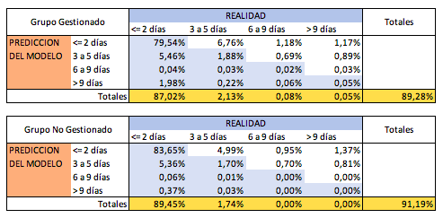